# Risk Factor Analysis

## Outcome Variable

**Outcome Variable:** wasted

## Predictor Variables

**Intervention Variable:** mwtkg

**Adjustment Set:**

- arm
- W_mage
- meducyrs
- feducyrs
- single
- brthmon
- W_parity
- delta_W_mage
- delta_meducyrs
- delta_feducyrs
- delta_single
- delta_brthmon
- delta_W_parity

## Stratifying Variables

The analysis was stratified on these variable(s):

- agecat
- studyid
- country

## Data Summary

| agecat | studyid | country | mwtkg | wasted | n_cell | n |
| --- | --- | --- | --- | --- | --- | --- |
| Birth | JiVitA-3 | BANGLADESH | >=58 kg | 0 | 383 | 17995 |
| Birth | JiVitA-3 | BANGLADESH | >=58 kg | 1 | 44 | 17995 |
| Birth | JiVitA-3 | BANGLADESH | <52 kg | 0 | 14554 | 17995 |
| Birth | JiVitA-3 | BANGLADESH | <52 kg | 1 | 1797 | 17995 |
| Birth | JiVitA-3 | BANGLADESH | [52-58) kg | 0 | 1086 | 17995 |
| Birth | JiVitA-3 | BANGLADESH | [52-58) kg | 1 | 131 | 17995 |
| Birth | MAL-ED | BANGLADESH | >=58 kg | 0 | 34 | 209 |
| Birth | MAL-ED | BANGLADESH | >=58 kg | 1 | 3 | 209 |
| Birth | MAL-ED | BANGLADESH | <52 kg | 0 | 107 | 209 |
| Birth | MAL-ED | BANGLADESH | <52 kg | 1 | 24 | 209 |
| Birth | MAL-ED | BANGLADESH | [52-58) kg | 0 | 33 | 209 |
| Birth | MAL-ED | BANGLADESH | [52-58) kg | 1 | 8 | 209 |
| Birth | MAL-ED | BRAZIL | >=58 kg | 0 | 33 | 61 |
| Birth | MAL-ED | BRAZIL | >=58 kg | 1 | 0 | 61 |
| Birth | MAL-ED | BRAZIL | <52 kg | 0 | 13 | 61 |
| Birth | MAL-ED | BRAZIL | <52 kg | 1 | 1 | 61 |
| Birth | MAL-ED | BRAZIL | [52-58) kg | 0 | 13 | 61 |
| Birth | MAL-ED | BRAZIL | [52-58) kg | 1 | 1 | 61 |
| Birth | MAL-ED | INDIA | >=58 kg | 0 | 6 | 41 |
| Birth | MAL-ED | INDIA | >=58 kg | 1 | 0 | 41 |
| Birth | MAL-ED | INDIA | <52 kg | 0 | 23 | 41 |
| Birth | MAL-ED | INDIA | <52 kg | 1 | 5 | 41 |
| Birth | MAL-ED | INDIA | [52-58) kg | 0 | 7 | 41 |
| Birth | MAL-ED | INDIA | [52-58) kg | 1 | 0 | 41 |
| Birth | MAL-ED | NEPAL | >=58 kg | 0 | 9 | 26 |
| Birth | MAL-ED | NEPAL | >=58 kg | 1 | 0 | 26 |
| Birth | MAL-ED | NEPAL | <52 kg | 0 | 6 | 26 |
| Birth | MAL-ED | NEPAL | <52 kg | 1 | 1 | 26 |
| Birth | MAL-ED | NEPAL | [52-58) kg | 0 | 9 | 26 |
| Birth | MAL-ED | NEPAL | [52-58) kg | 1 | 1 | 26 |

[output cut: 240 more lines]

The following strata were considered:

- agecat: 24 months, studyid: JiVitA-3, country: BANGLADESH
- agecat: 24 months, studyid: LCNI-5, country: MALAWI
- agecat: 24 months, studyid: MAL-ED, country: BANGLADESH
- agecat: 24 months, studyid: MAL-ED, country: BRAZIL
- agecat: 24 months, studyid: MAL-ED, country: INDIA
- agecat: 24 months, studyid: MAL-ED, country: NEPAL
- agecat: 24 months, studyid: MAL-ED, country: PERU
- agecat: 24 months, studyid: MAL-ED, country: SOUTH AFRICA
- agecat: 24 months, studyid: MAL-ED, country: TANZANIA, UNITED REPUBLIC OF
- agecat: 24 months, studyid: NIH-Birth, country: BANGLADESH
- agecat: 24 months, studyid: NIH-Crypto, country: BANGLADESH
- agecat: 24 months, studyid: PROBIT, country: BELARUS
- agecat: 24 months, studyid: PROVIDE, country: BANGLADESH
- agecat: 24 months, studyid: TanzaniaChild2, country: TANZANIA, UNITED REPUBLIC OF
- agecat: 24 months, studyid: ZVITAMBO, country: ZIMBABWE
- agecat: 6 months, studyid: JiVitA-3, country: BANGLADESH
- agecat: 6 months, studyid: LCNI-5, country: MALAWI
- agecat: 6 months, studyid: MAL-ED, country: BANGLADESH
- agecat: 6 months, studyid: MAL-ED, country: BRAZIL
- agecat: 6 months, studyid: MAL-ED, country: INDIA
- agecat: 6 months, studyid: MAL-ED, country: NEPAL
- agecat: 6 months, studyid: MAL-ED, country: PERU
- agecat: 6 months, studyid: MAL-ED, country: SOUTH AFRICA
- agecat: 6 months, studyid: MAL-ED, country: TANZANIA, UNITED REPUBLIC OF
- agecat: 6 months, studyid: NIH-Birth, country: BANGLADESH
- agecat: 6 months, studyid: NIH-Crypto, country: BANGLADESH
- agecat: 6 months, studyid: PROBIT, country: BELARUS
- agecat: 6 months, studyid: PROVIDE, country: BANGLADESH
- agecat: 6 months, studyid: SAS-CompFeed, country: INDIA
- agecat: 6 months, studyid: TanzaniaChild2, country: TANZANIA, UNITED REPUBLIC OF
- agecat: 6 months, studyid: ZVITAMBO, country: ZIMBABWE
- agecat: Birth, studyid: JiVitA-3, country: BANGLADESH
- agecat: Birth, studyid: MAL-ED, country: BANGLADESH
- agecat: Birth, studyid: MAL-ED, country: BRAZIL
- agecat: Birth, studyid: MAL-ED, country: INDIA
- agecat: Birth, studyid: MAL-ED, country: NEPAL
- agecat: Birth, studyid: MAL-ED, country: PERU
- agecat: Birth, studyid: MAL-ED, country: SOUTH AFRICA
- agecat: Birth, studyid: MAL-ED, country: TANZANIA, UNITED REPUBLIC OF
- agecat: Birth, studyid: NIH-Birth, country: BANGLADESH
- agecat: Birth, studyid: NIH-Crypto, country: BANGLADESH
- agecat: Birth, studyid: PROBIT, country: BELARUS
- agecat: Birth, studyid: PROVIDE, country: BANGLADESH
- agecat: Birth, studyid: SAS-CompFeed, country: INDIA
- agecat: Birth, studyid: ZVITAMBO, country: ZIMBABWE

### Dropped Strata

Some strata were dropped due to rare outcomes:

- agecat: Birth, studyid: MAL-ED, country: BANGLADESH
- agecat: Birth, studyid: MAL-ED, country: BRAZIL
- agecat: Birth, studyid: MAL-ED, country: INDIA
- agecat: Birth, studyid: MAL-ED, country: NEPAL
- agecat: Birth, studyid: MAL-ED, country: PERU
- agecat: Birth, studyid: MAL-ED, country: SOUTH AFRICA
- agecat: Birth, studyid: MAL-ED, country: TANZANIA, UNITED REPUBLIC OF
- agecat: 6 months, studyid: LCNI-5, country: MALAWI
- agecat: 6 months, studyid: MAL-ED, country: BANGLADESH
- agecat: 6 months, studyid: MAL-ED, country: BRAZIL
- agecat: 6 months, studyid: MAL-ED, country: INDIA
- agecat: 6 months, studyid: MAL-ED, country: NEPAL
- agecat: 6 months, studyid: MAL-ED, country: PERU
- agecat: 6 months, studyid: MAL-ED, country: SOUTH AFRICA
- agecat: 6 months, studyid: MAL-ED, country: TANZANIA, UNITED REPUBLIC OF
- agecat: 6 months, studyid: NIH-Birth, country: BANGLADESH
- agecat: 6 months, studyid: NIH-Crypto, country: BANGLADESH
- agecat: 6 months, studyid: PROVIDE, country: BANGLADESH
- agecat: 24 months, studyid: LCNI-5, country: MALAWI
- agecat: 24 months, studyid: MAL-ED, country: BANGLADESH
- agecat: 24 months, studyid: MAL-ED, country: BRAZIL
- agecat: 24 months, studyid: MAL-ED, country: INDIA
- agecat: 24 months, studyid: MAL-ED, country: NEPAL
- agecat: 24 months, studyid: MAL-ED, country: PERU
- agecat: 24 months, studyid: MAL-ED, country: SOUTH AFRICA
- agecat: 24 months, studyid: MAL-ED, country: TANZANIA, UNITED REPUBLIC OF
- agecat: 24 months, studyid: NIH-Birth, country: BANGLADESH
- agecat: 24 months, studyid: PROBIT, country: BELARUS
- agecat: 24 months, studyid: TanzaniaChild2, country: TANZANIA, UNITED REPUBLIC OF

## Methods Detail

We’re interested in the causal parameters $E[Y_a]$ for all values of $a \in \mathcal{A}$. These parameters represent the mean outcome if, possibly contrary to fact, we intervened to set all units to have $A=a$. Under the randomization and positivity assumptions, these are identified by the statistical parameters $\psi_a=E_W[E_{Y|A,W}(Y|A=a,W)]$. In addition, we’re interested in the mean of $Y$, $E[Y]$ under no intervention (the observed mean). We will estimate these parameters by using SuperLearner to fit the relevant likelihood factors – $E_{Y|A,W}(Y|A=a,W)$ and $p(A=a|W)$, and then updating our likelihood fit using a joint TMLE.

For unadjusted analyses ($W=\{\}$), initial likelihoods were estimated using Lrnr_glm to estimate the simple $E(Y|A)$ and Lrnr_mean to estimate $p(A)$. For adjusted analyses, a small library containing Lrnr_glmnet, Lrnr_xgboost, and Lrnr_mean was used.

Having estimated these parameters, we will then use the delta method to estimate relative risks and attributable risks relative to a prespecified baseline level of $A$.

# Results Detail

## Results Plots

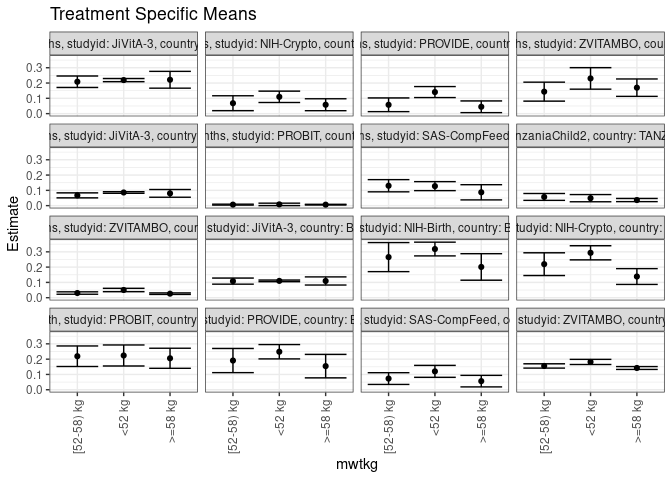

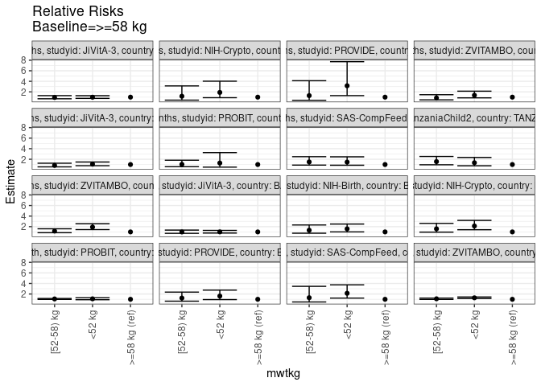

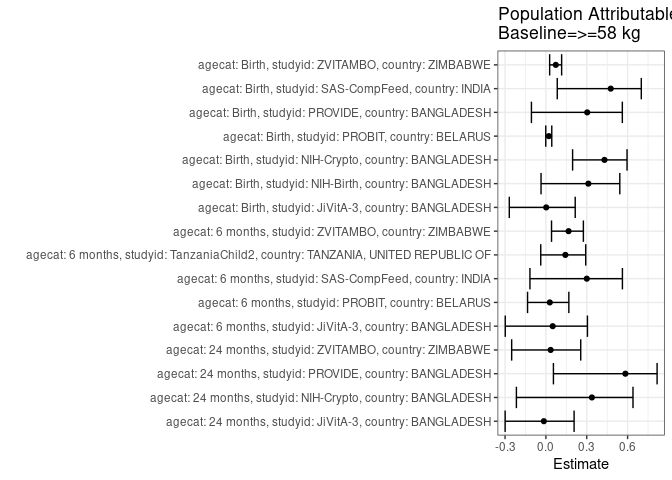

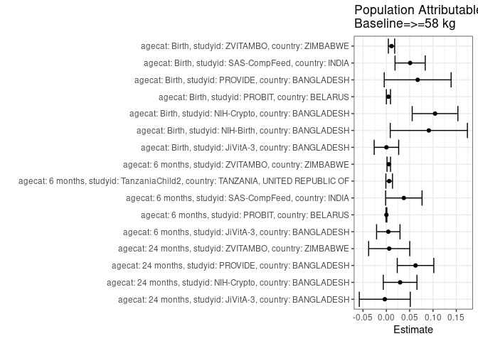

## Results Table

### Parameter: TSM

| agecat | studyid | country | intervention_level | baseline_level | estimate | ci_lower | ci_upper |
| --- | --- | --- | --- | --- | --- | --- | --- |
| Birth | JiVitA-3 | BANGLADESH | >=58 kg | NA | 0.1093511 | 0.0828193 | 0.1358829 |
| Birth | JiVitA-3 | BANGLADESH | <52 kg | NA | 0.1098961 | 0.1045849 | 0.1152072 |
| Birth | JiVitA-3 | BANGLADESH | [52-58) kg | NA | 0.1082969 | 0.0883108 | 0.1282830 |
| Birth | NIH-Birth | BANGLADESH | >=58 kg | NA | 0.2010628 | 0.1143746 | 0.2877509 |
| Birth | NIH-Birth | BANGLADESH | <52 kg | NA | 0.3181855 | 0.2732196 | 0.3631514 |
| Birth | NIH-Birth | BANGLADESH | [52-58) kg | NA | 0.2654248 | 0.1703751 | 0.3604746 |
| Birth | NIH-Crypto | BANGLADESH | >=58 kg | NA | 0.1384267 | 0.0867780 | 0.1900754 |
| Birth | NIH-Crypto | BANGLADESH | <52 kg | NA | 0.2935602 | 0.2473409 | 0.3397795 |
| Birth | NIH-Crypto | BANGLADESH | [52-58) kg | NA | 0.2192303 | 0.1449173 | 0.2935432 |
| Birth | PROBIT | BELARUS | >=58 kg | NA | 0.2056909 | 0.1401223 | 0.2712595 |
| Birth | PROBIT | BELARUS | <52 kg | NA | 0.2239329 | 0.1552370 | 0.2926288 |
| Birth | PROBIT | BELARUS | [52-58) kg | NA | 0.2190769 | 0.1518450 | 0.2863088 |
| Birth | PROVIDE | BANGLADESH | >=58 kg | NA | 0.1543497 | 0.0776009 | 0.2310984 |
| Birth | PROVIDE | BANGLADESH | <52 kg | NA | 0.2484940 | 0.2017212 | 0.2952668 |
| Birth | PROVIDE | BANGLADESH | [52-58) kg | NA | 0.1908260 | 0.1118925 | 0.2697595 |
| Birth | SAS-CompFeed | INDIA | >=58 kg | NA | 0.0561798 | 0.0184587 | 0.0939008 |
| Birth | SAS-CompFeed | INDIA | <52 kg | NA | 0.1201456 | 0.0811367 | 0.1591546 |
| Birth | SAS-CompFeed | INDIA | [52-58) kg | NA | 0.0730337 | 0.0346496 | 0.1114178 |
| Birth | ZVITAMBO | ZIMBABWE | >=58 kg | NA | 0.1421906 | 0.1328184 | 0.1515627 |
| Birth | ZVITAMBO | ZIMBABWE | <52 kg | NA | 0.1817596 | 0.1650223 | 0.1984969 |
| Birth | ZVITAMBO | ZIMBABWE | [52-58) kg | NA | 0.1555150 | 0.1414702 | 0.1695598 |
| 6 months | JiVitA-3 | BANGLADESH | >=58 kg | NA | 0.0803593 | 0.0549803 | 0.1057384 |
| 6 months | JiVitA-3 | BANGLADESH | <52 kg | NA | 0.0860910 | 0.0810486 | 0.0911333 |
| 6 months | JiVitA-3 | BANGLADESH | [52-58) kg | NA | 0.0672246 | 0.0508455 | 0.0836037 |
| 6 months | PROBIT | BELARUS | >=58 kg | NA | 0.0064688 | 0.0042416 | 0.0086961 |
| 6 months | PROBIT | BELARUS | <52 kg | NA | 0.0083102 | 0.0002681 | 0.0163524 |
| 6 months | PROBIT | BELARUS | [52-58) kg | NA | 0.0066905 | 0.0036382 | 0.0097427 |
| 6 months | SAS-CompFeed | INDIA | >=58 kg | NA | 0.0873786 | 0.0376907 | 0.1370666 |
| 6 months | SAS-CompFeed | INDIA | <52 kg | NA | 0.1275964 | 0.0982369 | 0.1569559 |
| 6 months | SAS-CompFeed | INDIA | [52-58) kg | NA | 0.1302326 | 0.0903997 | 0.1700654 |
| 6 months | TanzaniaChild2 | TANZANIA, UNITED REPUBLIC OF | >=58 kg | NA | 0.0366400 | 0.0262391 | 0.0470409 |
| 6 months | TanzaniaChild2 | TANZANIA, UNITED REPUBLIC OF | <52 kg | NA | 0.0490044 | 0.0254078 | 0.0726010 |
| 6 months | TanzaniaChild2 | TANZANIA, UNITED REPUBLIC OF | [52-58) kg | NA | 0.0568877 | 0.0344291 | 0.0793463 |
| 6 months | ZVITAMBO | ZIMBABWE | >=58 kg | NA | 0.0263113 | 0.0214452 | 0.0311775 |
| 6 months | ZVITAMBO | ZIMBABWE | <52 kg | NA | 0.0503235 | 0.0394357 | 0.0612112 |
| 6 months | ZVITAMBO | ZIMBABWE | [52-58) kg | NA | 0.0305399 | 0.0227706 | 0.0383093 |
| 24 months | JiVitA-3 | BANGLADESH | >=58 kg | NA | 0.2213592 | 0.1663684 | 0.2763501 |
| 24 months | JiVitA-3 | BANGLADESH | <52 kg | NA | 0.2191868 | 0.2089284 | 0.2294451 |
| 24 months | JiVitA-3 | BANGLADESH | [52-58) kg | NA | 0.2084839 | 0.1710358 | 0.2459319 |
| 24 months | NIH-Crypto | BANGLADESH | >=58 kg | NA | 0.0579710 | 0.0189437 | 0.0969984 |
| 24 months | NIH-Crypto | BANGLADESH | <52 kg | NA | 0.1098901 | 0.0727545 | 0.1470257 |
| 24 months | NIH-Crypto | BANGLADESH | [52-58) kg | NA | 0.0679612 | 0.0193093 | 0.1166131 |
| 24 months | PROVIDE | BANGLADESH | >=58 kg | NA | 0.0446429 | 0.0063627 | 0.0829230 |
| 24 months | PROVIDE | BANGLADESH | <52 kg | NA | 0.1408840 | 0.1050144 | 0.1767536 |
| 24 months | PROVIDE | BANGLADESH | [52-58) kg | NA | 0.0576923 | 0.0128423 | 0.1025423 |
| 24 months | ZVITAMBO | ZIMBABWE | >=58 kg | NA | 0.1696399 | 0.1128304 | 0.2264494 |
| 24 months | ZVITAMBO | ZIMBABWE | <52 kg | NA | 0.2301094 | 0.1597453 | 0.3004735 |
| 24 months | ZVITAMBO | ZIMBABWE | [52-58) kg | NA | 0.1435532 | 0.0815418 | 0.2055646 |

### Parameter: E(Y)

| agecat | studyid | country | intervention_level | baseline_level | estimate | ci_lower | ci_upper |
| --- | --- | --- | --- | --- | --- | --- | --- |
| Birth | JiVitA-3 | BANGLADESH | NA | NA | 0.1095860 | 0.1044555 | 0.1147165 |
| Birth | NIH-Birth | BANGLADESH | NA | NA | 0.2921739 | 0.2549711 | 0.3293768 |
| Birth | NIH-Crypto | BANGLADESH | NA | NA | 0.2428977 | 0.2111977 | 0.2745977 |
| Birth | PROBIT | BELARUS | NA | NA | 0.2101650 | 0.1447462 | 0.2755839 |
| Birth | PROVIDE | BANGLADESH | NA | NA | 0.2215686 | 0.1854897 | 0.2576475 |
| Birth | SAS-CompFeed | INDIA | NA | NA | 0.1072411 | 0.0763212 | 0.1381609 |
| Birth | ZVITAMBO | ZIMBABWE | NA | NA | 0.1533152 | 0.1463521 | 0.1602782 |
| 6 months | JiVitA-3 | BANGLADESH | NA | NA | 0.0845902 | 0.0797842 | 0.0893962 |
| 6 months | PROBIT | BELARUS | NA | NA | 0.0066595 | 0.0045730 | 0.0087461 |
| 6 months | SAS-CompFeed | INDIA | NA | NA | 0.1249059 | 0.0994146 | 0.1503973 |
| 6 months | TanzaniaChild2 | TANZANIA, UNITED REPUBLIC OF | NA | NA | 0.0427565 | 0.0338612 | 0.0516519 |
| 6 months | ZVITAMBO | ZIMBABWE | NA | NA | 0.0315660 | 0.0277605 | 0.0353714 |
| 24 months | JiVitA-3 | BANGLADESH | NA | NA | 0.2180740 | 0.2082038 | 0.2279441 |
| 24 months | NIH-Crypto | BANGLADESH | NA | NA | 0.0875486 | 0.0630907 | 0.1120065 |
| 24 months | PROVIDE | BANGLADESH | NA | NA | 0.1072664 | 0.0820169 | 0.1325160 |
| 24 months | ZVITAMBO | ZIMBABWE | NA | NA | 0.1757720 | 0.1393703 | 0.2121737 |

### Parameter: RR

| agecat | studyid | country | intervention_level | baseline_level | estimate | ci_lower | ci_upper |
| --- | --- | --- | --- | --- | --- | --- | --- |
| Birth | JiVitA-3 | BANGLADESH | >=58 kg | >=58 kg | 1.0000000 | 1.0000000 | 1.000000 |
| Birth | JiVitA-3 | BANGLADESH | <52 kg | >=58 kg | 1.0049832 | 0.7851320 | 1.286397 |
| Birth | JiVitA-3 | BANGLADESH | [52-58) kg | >=58 kg | 0.9903591 | 0.7298893 | 1.343781 |
| Birth | NIH-Birth | BANGLADESH | >=58 kg | >=58 kg | 1.0000000 | 1.0000000 | 1.000000 |
| Birth | NIH-Birth | BANGLADESH | <52 kg | >=58 kg | 1.5825184 | 1.0049413 | 2.492050 |
| Birth | NIH-Birth | BANGLADESH | [52-58) kg | >=58 kg | 1.3201095 | 0.7540739 | 2.311032 |
| Birth | NIH-Crypto | BANGLADESH | >=58 kg | >=58 kg | 1.0000000 | 1.0000000 | 1.000000 |
| Birth | NIH-Crypto | BANGLADESH | <52 kg | >=58 kg | 2.1206909 | 1.4136470 | 3.181367 |
| Birth | NIH-Crypto | BANGLADESH | [52-58) kg | >=58 kg | 1.5837284 | 0.9578154 | 2.618663 |
| Birth | PROBIT | BELARUS | >=58 kg | >=58 kg | 1.0000000 | 1.0000000 | 1.000000 |
| Birth | PROBIT | BELARUS | <52 kg | >=58 kg | 1.0886863 | 0.9216799 | 1.285954 |
| Birth | PROBIT | BELARUS | [52-58) kg | >=58 kg | 1.0650781 | 0.9862181 | 1.150244 |
| Birth | PROVIDE | BANGLADESH | >=58 kg | >=58 kg | 1.0000000 | 1.0000000 | 1.000000 |
| Birth | PROVIDE | BANGLADESH | <52 kg | >=58 kg | 1.6099419 | 0.9460269 | 2.739788 |
| Birth | PROVIDE | BANGLADESH | [52-58) kg | >=58 kg | 1.2363224 | 0.6478084 | 2.359484 |
| Birth | SAS-CompFeed | INDIA | >=58 kg | >=58 kg | 1.0000000 | 1.0000000 | 1.000000 |
| Birth | SAS-CompFeed | INDIA | <52 kg | >=58 kg | 2.1385922 | 1.2224537 | 3.741309 |
| Birth | SAS-CompFeed | INDIA | [52-58) kg | >=58 kg | 1.3000000 | 0.4894687 | 3.452723 |
| Birth | ZVITAMBO | ZIMBABWE | >=58 kg | >=58 kg | 1.0000000 | 1.0000000 | 1.000000 |
| Birth | ZVITAMBO | ZIMBABWE | <52 kg | >=58 kg | 1.2782818 | 1.1414162 | 1.431559 |
| Birth | ZVITAMBO | ZIMBABWE | [52-58) kg | >=58 kg | 1.0937086 | 0.9780802 | 1.223007 |
| 6 months | JiVitA-3 | BANGLADESH | >=58 kg | >=58 kg | 1.0000000 | 1.0000000 | 1.000000 |
| 6 months | JiVitA-3 | BANGLADESH | <52 kg | >=58 kg | 1.0713251 | 0.7775499 | 1.476095 |
| 6 months | JiVitA-3 | BANGLADESH | [52-58) kg | >=58 kg | 0.8365505 | 0.5595874 | 1.250594 |
| 6 months | PROBIT | BELARUS | >=58 kg | >=58 kg | 1.0000000 | 1.0000000 | 1.000000 |
| 6 months | PROBIT | BELARUS | <52 kg | >=58 kg | 1.2846590 | 0.5056167 | 3.264031 |
| 6 months | PROBIT | BELARUS | [52-58) kg | >=58 kg | 1.0342594 | 0.5892762 | 1.815265 |
| 6 months | SAS-CompFeed | INDIA | >=58 kg | >=58 kg | 1.0000000 | 1.0000000 | 1.000000 |
| 6 months | SAS-CompFeed | INDIA | <52 kg | >=58 kg | 1.4602704 | 0.8663108 | 2.461460 |
| 6 months | SAS-CompFeed | INDIA | [52-58) kg | >=58 kg | 1.4904393 | 0.8935131 | 2.486152 |
| 6 months | TanzaniaChild2 | TANZANIA, UNITED REPUBLIC OF | >=58 kg | >=58 kg | 1.0000000 | 1.0000000 | 1.000000 |
| 6 months | TanzaniaChild2 | TANZANIA, UNITED REPUBLIC OF | <52 kg | >=58 kg | 1.3374566 | 0.7646668 | 2.339307 |
| 6 months | TanzaniaChild2 | TANZANIA, UNITED REPUBLIC OF | [52-58) kg | >=58 kg | 1.5526137 | 0.9548076 | 2.524707 |
| 6 months | ZVITAMBO | ZIMBABWE | >=58 kg | >=58 kg | 1.0000000 | 1.0000000 | 1.000000 |
| 6 months | ZVITAMBO | ZIMBABWE | <52 kg | >=58 kg | 1.9126157 | 1.4387949 | 2.542474 |
| 6 months | ZVITAMBO | ZIMBABWE | [52-58) kg | >=58 kg | 1.1607139 | 0.8474485 | 1.589780 |
| 24 months | JiVitA-3 | BANGLADESH | >=58 kg | >=58 kg | 1.0000000 | 1.0000000 | 1.000000 |
| 24 months | JiVitA-3 | BANGLADESH | <52 kg | >=58 kg | 0.9901858 | 0.7686358 | 1.275595 |
| 24 months | JiVitA-3 | BANGLADESH | [52-58) kg | >=58 kg | 0.9418351 | 0.6883880 | 1.288595 |
| 24 months | NIH-Crypto | BANGLADESH | >=58 kg | >=58 kg | 1.0000000 | 1.0000000 | 1.000000 |
| 24 months | NIH-Crypto | BANGLADESH | <52 kg | >=58 kg | 1.8956044 | 0.8924902 | 4.026169 |
| 24 months | NIH-Crypto | BANGLADESH | [52-58) kg | >=58 kg | 1.1723301 | 0.4388000 | 3.132082 |
| 24 months | PROVIDE | BANGLADESH | >=58 kg | >=58 kg | 1.0000000 | 1.0000000 | 1.000000 |
| 24 months | PROVIDE | BANGLADESH | <52 kg | >=58 kg | 3.1558011 | 1.2901595 | 7.719263 |
| 24 months | PROVIDE | BANGLADESH | [52-58) kg | >=58 kg | 1.2923077 | 0.4061679 | 4.111746 |
| 24 months | ZVITAMBO | ZIMBABWE | >=58 kg | >=58 kg | 1.0000000 | 1.0000000 | 1.000000 |
| 24 months | ZVITAMBO | ZIMBABWE | <52 kg | >=58 kg | 1.3564583 | 0.8630489 | 2.131953 |
| 24 months | ZVITAMBO | ZIMBABWE | [52-58) kg | >=58 kg | 0.8462234 | 0.4900487 | 1.461271 |

### Parameter: PAR

| agecat | studyid | country | intervention_level | baseline_level | estimate | ci_lower | ci_upper |
| --- | --- | --- | --- | --- | --- | --- | --- |
| Birth | JiVitA-3 | BANGLADESH | >=58 kg | NA | 0.0002349 | -0.0260405 | 0.0265102 |
| Birth | NIH-Birth | BANGLADESH | >=58 kg | NA | 0.0911112 | 0.0083802 | 0.1738421 |
| Birth | NIH-Crypto | BANGLADESH | >=58 kg | NA | 0.1044711 | 0.0554950 | 0.1534471 |
| Birth | PROBIT | BELARUS | >=58 kg | NA | 0.0044741 | 0.0000525 | 0.0088958 |
| Birth | PROVIDE | BANGLADESH | >=58 kg | NA | 0.0672189 | -0.0045112 | 0.1389491 |
| Birth | SAS-CompFeed | INDIA | >=58 kg | NA | 0.0510613 | 0.0186947 | 0.0834278 |
| Birth | ZVITAMBO | ZIMBABWE | >=58 kg | NA | 0.0111246 | 0.0043635 | 0.0178857 |
| 6 months | JiVitA-3 | BANGLADESH | >=58 kg | NA | 0.0042308 | -0.0208977 | 0.0293594 |
| 6 months | PROBIT | BELARUS | >=58 kg | NA | 0.0001907 | -0.0008192 | 0.0012005 |
| 6 months | SAS-CompFeed | INDIA | >=58 kg | NA | 0.0375273 | -0.0015559 | 0.0766105 |
| 6 months | TanzaniaChild2 | TANZANIA, UNITED REPUBLIC OF | >=58 kg | NA | 0.0061166 | -0.0010080 | 0.0132412 |
| 6 months | ZVITAMBO | ZIMBABWE | >=58 kg | NA | 0.0052546 | 0.0015222 | 0.0089871 |
| 24 months | JiVitA-3 | BANGLADESH | >=58 kg | NA | -0.0032853 | -0.0579471 | 0.0513766 |
| 24 months | NIH-Crypto | BANGLADESH | >=58 kg | NA | 0.0295776 | -0.0065257 | 0.0656810 |
| 24 months | PROVIDE | BANGLADESH | >=58 kg | NA | 0.0626236 | 0.0234443 | 0.1018028 |
| 24 months | ZVITAMBO | ZIMBABWE | >=58 kg | NA | 0.0061321 | -0.0379427 | 0.0502069 |

### Parameter: PAF

| agecat | studyid | country | intervention_level | baseline_level | estimate | ci_lower | ci_upper |
| --- | --- | --- | --- | --- | --- | --- | --- |
| Birth | JiVitA-3 | BANGLADESH | >=58 kg | NA | 0.0021431 | -0.2688788 | 0.2152771 |
| Birth | NIH-Birth | BANGLADESH | >=58 kg | NA | 0.3118388 | -0.0357068 | 0.5427607 |
| Birth | NIH-Crypto | BANGLADESH | >=58 kg | NA | 0.4301030 | 0.1960874 | 0.5959977 |
| Birth | PROBIT | BELARUS | >=58 kg | NA | 0.0212885 | -0.0010205 | 0.0431004 |
| Birth | PROVIDE | BANGLADESH | >=58 kg | NA | 0.3033775 | -0.1062696 | 0.5613340 |
| Birth | SAS-CompFeed | INDIA | >=58 kg | NA | 0.4761356 | 0.0833933 | 0.7005980 |
| Birth | ZVITAMBO | ZIMBABWE | >=58 kg | NA | 0.0725605 | 0.0275003 | 0.1155329 |
| 6 months | JiVitA-3 | BANGLADESH | >=58 kg | NA | 0.0500159 | -0.2985873 | 0.3050372 |
| 6 months | PROBIT | BELARUS | >=58 kg | NA | 0.0286335 | -0.1347673 | 0.1685055 |
| 6 months | SAS-CompFeed | INDIA | >=58 kg | NA | 0.3004445 | -0.1172837 | 0.5619932 |
| 6 months | TanzaniaChild2 | TANZANIA, UNITED REPUBLIC OF | >=58 kg | NA | 0.1430554 | -0.0378996 | 0.2924614 |
| 6 months | ZVITAMBO | ZIMBABWE | >=58 kg | NA | 0.1664652 | 0.0413267 | 0.2752690 |
| 24 months | JiVitA-3 | BANGLADESH | >=58 kg | NA | -0.0150649 | -0.2994340 | 0.2070727 |
| 24 months | NIH-Crypto | BANGLADESH | >=58 kg | NA | 0.3378422 | -0.2166810 | 0.6396320 |
| 24 months | PROVIDE | BANGLADESH | >=58 kg | NA | 0.5838134 | 0.0552311 | 0.8166628 |
| 24 months | ZVITAMBO | ZIMBABWE | >=58 kg | NA | 0.0348868 | -0.2514689 | 0.2557198 |